# Regression Modeling Features from HBO Series Game of Thrones

### **LOADING PACKAGES**

```r
library(knitr)
library(dplyr)
library(ggpubr)
library(jtools)
library(ggplot2)
library(tidyverse)
library(caret)
library(readr)
library(MASS)
library(leaps)
library(lmtest)
library(car)
opts_chunk$set(echo = TRUE)
```

### **ENTERING THE DATA**

```r
my_data <- read_csv("GoT-characters (1).csv")
head(my_data)
```

```
## # A tibble: 6 × 35
##      id name           sex religion occupation social_status allegiance_last
##   <dbl> <chr>        <dbl>    <dbl>      <dbl>         <dbl>           <dbl>
## 1   100 Waymar Royce     1        9          2             2               3
## 2   101 Gared Tuttle     1        9          2             2               3
## 3   102 Will             1        9          2             2               3
## 4   103 Irri             2        1          2             2               2
## 5   104 Jon Snow         1        4          2             1               3
## 6   105 Bran Stark       1        4          1             1               1
## # ℹ 28 more variables: allegiance_switched <dbl>, intro_season <dbl>,
## #   intro_episode <dbl>, intro_time_sec <dbl>, intro_time_hrs <dbl>,
## #   dth_flag <dbl>, dth_season <dbl>, dth_episode <dbl>, dth_time_sec <dbl>,
## #   dth_time_hrs <dbl>, censor_time_sec <dbl>, censor_time_hrs <dbl>,
## #   exp_season <dbl>, exp_episode <dbl>, exp_time_sec <dbl>,
## #   exp_time_hrs <dbl>, featured_episode_count <dbl>, prominence <dbl>,
## #   dth_description <chr>, icd10_dx_code <chr>, icd10_dx_text <chr>, …
```

### **DATA CLEANING**

```r
extracted_data <- subset(my_data, select=c("exp_time_hrs", "dth_flag", "sex", "social_status", "allegiance_switched", "occupation", "prominence"))
## Removing "unknown" from Sex = NONE FOUND
levels(as.factor(extracted_data$sex))
```

```
## [1] "1" "2"
```

```r
## Removing "unknown" from Social Status = NONE FOUND
levels(as.factor(extracted_data$social_status))
```

```
## [1] "1" "2"
```

```r
## Removing "unknown" from Allegiance Switched = NONE FOUND
levels(as.factor(extracted_data$allegiance_switched))
```

```
## [1] "1" "2"
```

```r
## Removing "unknown" from Occupation = 49 FOUND
levels(as.factor(extracted_data$occupation))
```

```
## [1] "1" "2" "9"
```

```r
table(extracted_data$occupation)
```

```
##
##   1   2   9
##  96 221  42
```

```r
new_data <-subset(extracted_data, extracted_data$occupation != 9)
table(new_data$occupation)
```

```
##
##   1   2
##  96 221
```

### **SETTING REFERENCE GROUPS**

```r
# For dth flag
new_data$dth_flag <- factor(new_data$dth_flag)
levels(new_data$dth_flag)
```

```
## [1] "0" "1"
```

```r
new_data$dth_flag <- recode_factor(new_data$dth_flag, "0" = "2")
new_data$dth_flag <- C(new_data$dth_flag, contr.treatment, base=2)
levels(new_data$dth_flag)
```

```
## [1] "2" "1"
```

```r
## For Sex
new_data$sex <- factor(new_data$sex)
new_data$sex <- C(new_data$sex, contr.treatment, base=1)
levels(new_data$sex)
```

```
## [1] "1" "2"
```

```r
## For Social Status
new_data$social_status <- factor(new_data$social_status)
new_data$social_status <- C(new_data$social_status, contr.treatment, base=1)
levels(new_data$social_status)
```

```
## [1] "1" "2"
```

```r
## For Allegiance Switched

new_data$allegiance_switched <- factor(new_data$allegiance_switched)
new_data$allegiance_switched <- C(new_data$allegiance_switched, contr.treatment, base=1)
levels(new_data$allegiance_switched)
```

```
## [1] "1" "2"
```

```r
## For Occupation
new_data$occupation <- factor(new_data$occupation)
new_data$occupation <- C(new_data$occupation, contr.treatment, base=1)
levels(new_data$occupation)
```

```
## [1] "1" "2"
```

## **RESOLUTIONS:**

### **QUESTION 1**: *(70 points) In this problem, the response is exp_time_hrs and the predictors are `dth_flag`, `sex`, `social_status`, `allegiance_switched`, `occupation`, and `prominence`.*

#### **Part A**: *(5 points) Draw a scatter plot of exp_time_hrs against prominence with different symbols/colors for different levels of dth_flag. Draw a second plot using the logarithm of prominence instead. Describe these two plots.*

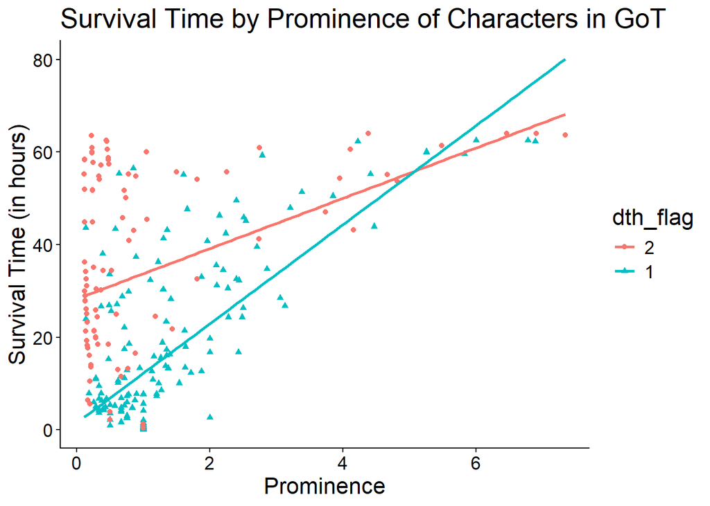

```r
## First Plot
ggplot(new_data, aes(x=prominence, y=exp_time_hrs, shape=dth_flag, color=dth_flag)) + geom_point()+ geom_smooth(method=lm, se=FALSE, fullrange= TRUE, level=0.95, linetype="solid", fill="blue")+theme_classic()+labs(title="Survival Time by Prominence of Characters in GoT", x="Prominence", y = "Survival Time (in hours)")+theme(text = element_text(size=16))
```

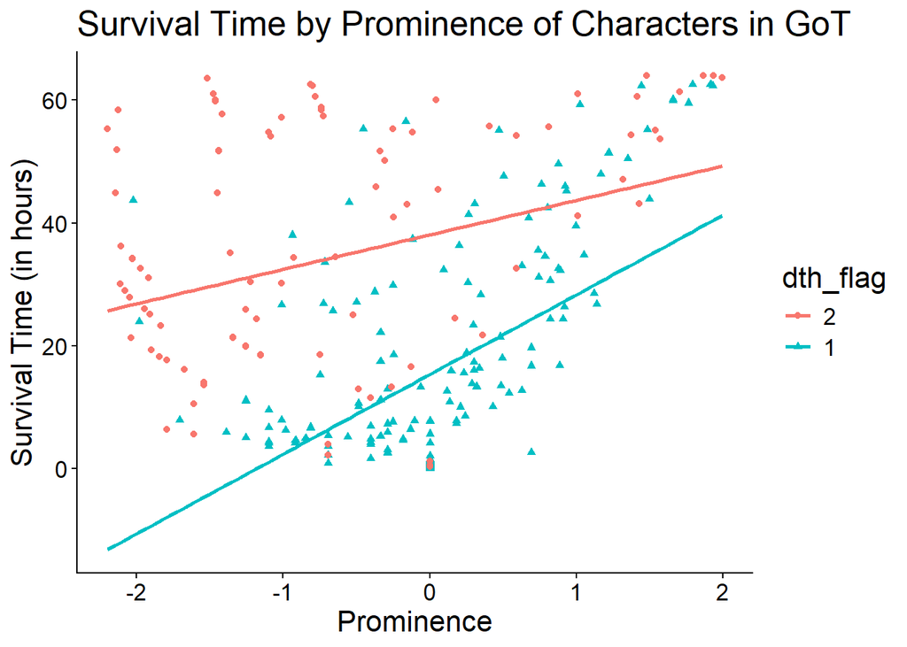

```r
## Second Plot
ggplot(new_data, aes(x=log(prominence), y=exp_time_hrs, shape=dth_flag, color=dth_flag)) + geom_point()+ geom_smooth(method=lm, se=FALSE, fullrange= TRUE, level=0.95, linetype="solid", fill="blue")+theme_classic()+labs(title="Survival Time by Prominence of Characters in GoT", x="Prominence", y = "Survival Time (in hours)")+theme(text = element_text(size=16))
```